# Engage Analysis

Oriol Tauleria

12 February 2022

## Objetivo

El objetivo de este estudio es entender qué es MITRE ENGAGE, como se relaciona con otros estándares de MITRE y como puede ser útil para una organización. Se estudiaran los datos oficiales proporcionados por la asociación MITRE en su [repositorio de github](https://github.com/mitre/engage), muy en detalle la información proporcionada en _data poniéndo especial émfasis en ENGAGE no tanto en su relación con attack.

## Introducción

MITRE ENGAGE es un framework para planificar y discutir como enfrentar o “engañar” a los enemigos y el bloqueo de sus actividades. Se nutre de comportamientos de enemigos observados en el mundo real y pretende impulsar resultados estratégicos de cyberseguridad.

ENGAGE es el reemplazo de MITRE Shield. Basándose en elfeedback recibido por la comunidad, MITRE ha decidido substituir la antigua Shield (una base de conocimiento) simplificandola y centrándose en las áreas de bloqueo, engaño y enfrentamiento del adversario.

#### ENGAGE desde el punto de vista del blue team

MITRE ENGAGE ofrece una aproximación organizada, procedimentada y estratégica para pasar de objetivos de prevención o para entender la información de un atacante a planes y a técnicas concretas. En resumen es un framework que ayudará a cualquier blue team a impulsar sus estrategias de Defensa Activa.

A diferencia de SHIELD ofrece las “Adversary Vulnerabilities” que permite a los defensores centrarse en los eslabones más débiles de la seguridad.

#### ENGAGE desde el punto de vista del red team

MITRE ENGAGE es una buena base para planificar tácticas de ofuscación sabiendo, de antemano, las acciones específicas que hará la víctima. Por otro lado también ofrece información sobre ataques con impacto y los grupos que los han perpetrado (sin llegar a dar datos específicos).

#### Relaciones con otros frameworks

ENGAGE se nutre de información del mundo real para determinar objetivos, aproximaciones y actividades que de forma proactiva ayuden a las organizaciones a protegerse de ataques. La información de estos ataques se puede vincular con el framework ATT&CK, de la propia MITRE, también. Siendo capaz de vincular tecnicas, tácticas y vulnerabiliades con las propuestas estrategicas de solución ofrecidas por ENGAGE.

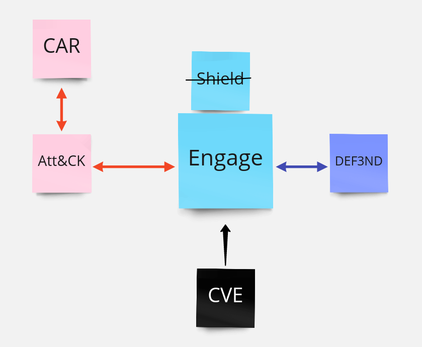

MITRE frameworks

### Elementos principales y arquitectura

ENGAGE es un framework que trabaja a 3 niveles distintos, a nivel de “goals”, de “approach” y de “activities”. Cada uno de estos niveles es un nivel de abstracción distinto (entraremos en mas detalle en los siguientes apartados).

Podemos ver como se relacionan los distintos elementos de los distintos niveles de abstracción (empezando por los objetivos (goals), las aproximaciones (approaches) y finalmente las actividades (activities)).

[interactive chart not shown]

### Objetivos (Goals)

Los objetivos son la necesidad a alto nivel que la organización persigue. En otras palabras, el primer paso para cualquier definición de operación de enfrentamiento al enemigo. Todas las actividades derivadas que podemos encontrar en engage ayudan a la organización a conseguir cada uno de estos objetivos a alto nivel.

Goals table

| id | name | description | type |
| --- | --- | --- | --- |
| EGO0001 | Expose | Reveal the presence of ongoing adversary operations. | Engagement |
| EGO0002 | Affect | Negatively impact the adversaries operations. | Engagement |
| EGO0003 | Elicit | Learn about adversaries tactics, techniques, and procedures. | Engagement |
| SGO0001 | Prepare | Help the defender think about what they want to accomplish with operations. | Strategic |
| SGO0002 | Understand | Make sure that the defender is capturing, utilizing, and refining knowledge learned to improve the defender’s posture. | Strategic |

Los Goals, como se puede observar en la tabla, se separan en “estratégicos” y de “enfrentamiento”. Los goals estrategicos ayudan a enfocarse en los espasos para completar antes, durante y después de una operación para asegurar que las actividades estan alineadas con la estrategia global. Los goals de enfrentamiento, ayudan a las organizaciones a identificar que acciones pueden tomarse en contra de enemigos y ayudan a progresar hacia reducir el impacto de un posible ataque.

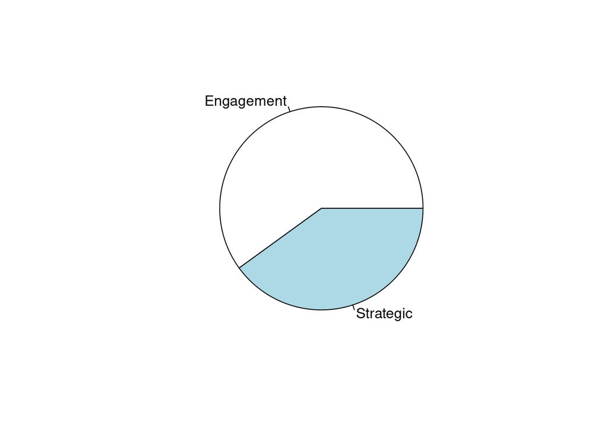

### Aproximaciones (Approaches)

Las aproximaciones son los planes en los que avanzar para conseguir los objetivos a alto nivel presentados en el apartado anterior.

Las Aproximaciones de ENGAGE ayudan a las organizaciones a identificar, priorizar y a organizar acciones específicas a tomar en contra de los enemigos.

Approaches table

| id | name | description | type |
| --- | --- | --- | --- |
| EAP0001 | Collection | Gather adversary tools, observe tactics, and collect other raw intelligence about the adversary’s activity. | Engagement |
| EAP0002 | Detection | Establish or maintain awareness in regard to adversary activity. | Engagement |
| EAP0003 | Prevention | Stop all or part of the adversary’s ability to conduct their operation as intended. | Engagement |
| EAP0004 | Direction | Encourage or discourage the adversary from conducting their operation as intended. | Engagement |
| EAP0005 | Disruption | Impair an adversary’s ability to conduct their operation as intended. | Engagement |
| EAP0006 | Reassurance | Add authenticity to deceptive components to convince an adversary that an environment is real. | Engagement |
| EAP0007 | Motivation | Encourage an adversary to conduct part or all of their mission. | Engagement |
| SAP0001 | Planning | Identify and align an operation with a desired end-state. | Strategic |
| SAP0002 | Analysis | Retrospective review of information gained from an operation . | Strategic |

Como en el caso de los objetivos, tambien podemos separar las aproximaciones en estratégicas y de enfrentamiento. Las aproximaciones estratégicas ayudan a alinear cada actividad con la estrategia global. las aproximaciones de enfrentamiento ayudan a identificar qué acciones puede tomar la organización en contra de un enemigo y para reducir su impacto.

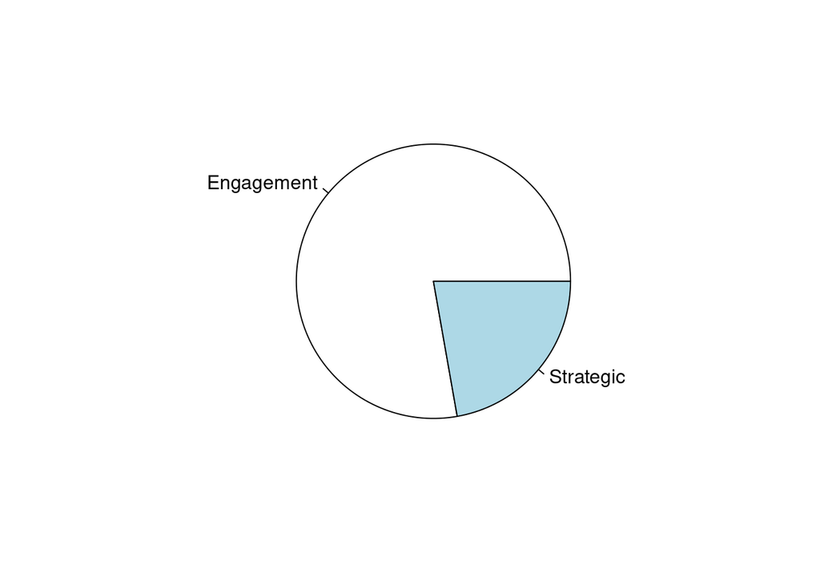

### Actividades (Activities)

Las actividades son las técnicas específicas que las organizaciones emplean para conseguir los objetivos a alto nivel. Al ser mas específicas tenemos un número significativamente mayor, comparandolos con las técnicas y los objetivos.

Activities table

| id | name | description |
| --- | --- | --- |
| EAC0001 | API Monitoring | Monitor local APIs that might be used by adversary tools and activity. |
| EAC0002 | Network Monitoring | Monitor network traffic in order to detect adversary activity. |
| EAC0003 | System Activity Monitoring | Collect system activity logs that can reveal adversary activity. |
| EAC0004 | Network Analysis | Analyze network traffic to gain intelligence on communications between systems. |
| EAC0005 | Decoy Artifacts and Systems | Introduce impersonations to expand the scope of a deceptive story. |
| EAC0006 | Application Diversity | Present the adversary with a variety of installed applications and services. |
| EAC0007 | Network Diversity | Use a diverse set of devices on the network to help establish the legitimacy of a decoy network. |
| EAC0008 | Burn-In | Exercise a target system in a manner where it will generate desirable system artifacts. |
| EAC0009 | Email Manipulation | Modify the flow of email in the environment. |
| EAC0010 | Peripheral Management | Manage peripheral devices used on systems within the network for engagement purposes. |
| EAC0011 | Pocket Litter | Place data on a system to reinforce the legitimacy of the system or user. |
| EAC0012 | Personas | Create fictitious human user(s) through a combination of planted data and revealed behavior patterns. |
| EAC0013 | Detonate Malware | Execute malware under controlled conditions to analyze its functionality. |
| EAC0014 | Software Manipulation | Make changes to a system’s software properties and functions to achieve a desired effect. |
| EAC0015 | Information Manipulation | Conceal and reveal both facts and fictions to support a deception story |
| EAC0016 | Network Manipulation | Make changes to network properties and functions to achieve a desired effect. |
| EAC0017 | Hardware Manipulation | Alter the hardware configuration of a system to limit what an adversary can do with the device. |
| EAC0018 | Security Controls | Alter security controls to make the system more or less vulnerable to attack. |
| EAC0019 | Baseline | Identify key system elements to establish a baseline and be prepared to reset a system to that baseline when necessary. |
| EAC0020 | Isolation | Configure devices, systems, networks, etc. to contain activity and data, thus preventing the expansion an engagement beyond desired limits. |
| EAC0021 | Migrate Attack Vector | Move a malicious link, file, or device from its intended location to a decoy system or network for execution/use. |
| EAC0022 | Artifact Diversity | Present the adversary with a variety of network and system artifacts. |
| SAC0001 | Strategic Goal | Define the objective of the desired end-state of your adversary engagement operations. |
| SAC0002 | Persona Creation | Plan and create a fictitious human user through a combination of planted data and revealed behavior patterns in support of your strategic objectives |
| SAC0003 | Storyboarding | Plan and create the deception story. |
| SAC0004 | Develop Threat Model | Identify, understand, and prioritize potential engagement targets. |
| SAC0005 | Define Exit Criteria | Define the set of events that would lead to the unnegotiable conclusion to the operation. |
| SAC0006 | Hotwash | Review the retrospective of operational activities. |
| SAC0007 | Refine Operation Activities | Update and improve the implementation of operational activities to better achieve the strategic goal. |
| SAC0008 | Distill Intelligence | Turn raw data gained during an operation into actionable intelligence. |
| SAC0009 | Inform Threat Model | Update existing threat models based on intelligence gained during engagement operation. |

Como en el caso de las aproximaciones, tambien podemos separar las actividades en estratégicas y de enfrentamiento. Las actividades estratégicas ayudan a alinear cada acción específica con los objetivos y la estrategia global. Las actividades de enfrentamiento pueden ser ejecutadas por la organización en contra de un enemigo y para reducir el impacto de dicho enemigo.

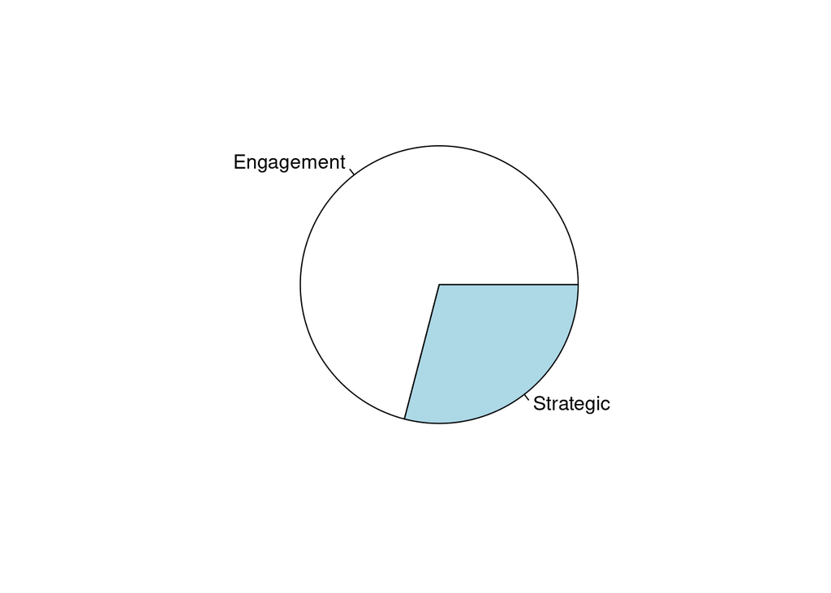

### Relaciones con otros frameworks

Como podemos ver al inicio de este informe, ENGAGE se relaciona con otros estándares como la base de conocimiento CVE y con los frameworks ATT&CK y DEF3ND. Vamos a centrarnos en la exploración de su relación con ATT&CK.

#### MITRE ATT&CK

ATT&CK es una base de conocimiento de tácticas y técnicas que utilizan (o pueden utiizar) cyberenemigos, basada en la observación de situaciones reales. Se utiliza como base para desarrollar modelos de amenaza y metodologias en productos y serivicios de cyberseguridad. Por este motivo es de principal relevancia identificar que relación existen entre las actividades propuestas por ENGAGE y los riesgos (tácticas y técnicas) recopiladas por ATT&CK.

Para este informe es necesario saber que ATT&CK organiza su base de conocimiento en tipologías de tácticas (empresa, mobile) (unas 14 para cada tipología) y que dentro de estas tácticas (que representan el “porqué” de una técnica o conjunto de técnicas y subtecnicas, o en otras palabras:“qué quiere conseguir un enemigo”.) Las técnicas (que existen muchísimas mas que técnicas) son el “cómo” un enemigo espera conseguir resultados en una táctica específica.

Por ejemplo; una táctica podría ser “Conseguir acceso privilegiado” y una técnica podría ser “hacer un dump de credenciales de otros usuarios”.

#### Relación a bajo nivel con Att&ck

El objetivo de ENGAGE es proporcionar un framework transversal de alto a bajo nivel de defensa activa. MITRE proporciona información sobre threat modeling via Att&ck, por lo tanto no es de extrañar que existe una fuerte relación entre los dos frameworks.

En la siguiente imágen podemos ver el mapeo a bajo nivel entre actividades de Engage y elementos de Att&ck.

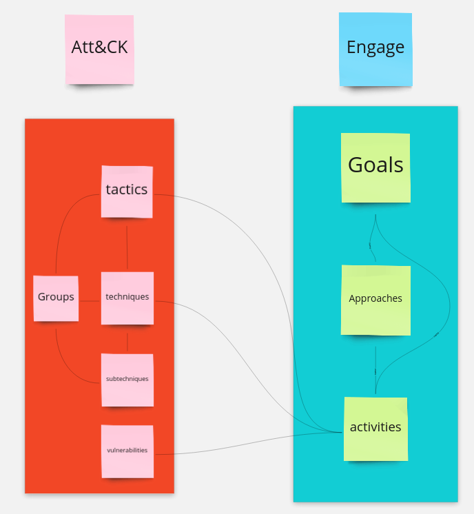

Engage y Att&ck

Por los motivos anteriormente comentados vamos a centrarnos en la relación entre las actividades de ENGAGE y y las técnicas de ataque de ATT&CK (sin entrar al detalle de que subtécnicas específicas se estan mitigando).

Para tratar la relación vamos a adaptar los datos de ATT&CK y ENGAGE, haciéndole una aproximación numérica eliminando los prefijos “T” y “EAC”.

En el siguiente gráfico podemos ver la relación entre los dos frameworks.

Observando el gráfico vemos que hay una falta de protección para las tácticas de att&ck entre los T1230 y los T1450, pero analizando att&ck vemos que estos IDs representan elementos antiguos (deprecados) o de mobile, a los que ENGAGE no aplica.

Tambien se puede obserar que la cobertuda de los elementos fuera de estos números es realmente amplia.

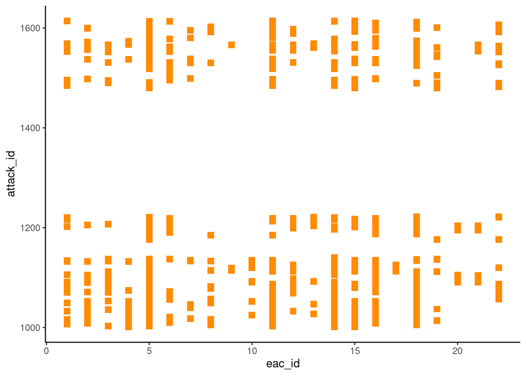

### Conclusion

Ahora que ya entendemos los distintos niveles de abstracción del framework, revisitemos la foto completa de sus relaciones, para poder diseñar una estrategia de defensa activa basada en un framework que recoje datos de la industria “en tiempo real”.

[interactive chart not shown]

Engage, ofrece un alineamiento claro, lineal y ejecutable desde la parte estratégica (goals) a la parte táctica (actividades), definiendo caminos de actuación (aproximaciones). Con este framework, mas allá de una base de conocimiento MITRE pone a disposición del público general una herramienta estratégica clave para la cyberprotección.

Es notorio ver el desequilibrio entre elementos de ´Engagement” y “Strategic”, teniendo claro que el framework se enfoca a enfrentamiento, dandole un enfoque muy prátcio, pero reservando algunos elementos de trabajo a la visión estratégica, como se espera de un framework a este nivel.

Engage, como sustituto de Shield, ofrece un soporte extensivo para la protección estratégica de técnicas y tácticas recogidas en Att&ck.

Seria necesaria una exploración en mas profundidad de los datos a nivel de mapeo de técnicas Attack y aproximaciones Engage para poder efinir ciclos de “foco” en vulnerabilidades específicas, pero se escapa del scope de este informe.

Seria interesante, pero se escapa del scope de este informe, analizar qué tipología de técnicas y ataques quedan cubiertas para determinar hacia donde tiene que evolucionar MITRE ENGAGE para ofrecer una herramienta holística de estratégia de defensa activa. Y no solo qué porcentages, sinó que relaciones, por objetivos podemos encontrar.